# 02_DE

Author

Qian Hui TAN

Published

June 5, 2023

# 1 02c_DE_MvsS

In this notebook, we analyze how similar CCSER1_S and CCSER1_M are. We do this in two ways:

- Pairwise crossplot
- Venn diagram

For convenience, we refer to CCSER1_M as M, and CCSER1_S as S.

In essence, we are asking: If a gene goes up in S, does it also go up in M? Do both M and S affect similar, or different pathways?

# 2 Setup

```r
source("../scripts/R/functions.R")
source("../scripts/R/clustering_functions.R")
source("../scripts/R/DE_functions.R")
suppressPackageStartupMessages({
  library(DESeq2)
  library(GenomicFeatures)
  library(RColorBrewer)
  library(gplots)
  library(biomaRt)
  library(grid)
  library(gridExtra)
  library(ggplot2)
  library(lattice)
  library(reshape)
  library(geneplotter)
  library(ggrepel)
  library(limma)
  library(tidyverse)
  library(eulerr)
  library(gghighlight)
  library(clusterProfiler)
  library(org.Dr.eg.db)
    # For GSEA
  library(fgsea) #biocmanager install
  library(msigdbr)
  library(knitr)
})
```

```r
## If the output directory doesn't exist, create it
if(!dir.exists("../output/02_DE")){
  dir.create("../output/02_DE")
}

output_dir <- "../output/02_DE/"
```

## 2.1 Function

```r
highlight_reactome <- function(pathways,
                               df_plot,
                               subtitle = "subtitle",
                               label = FALSE){

  df_plot <- df_plot %>%
    mutate(signif = case_when(
      pathway %in% pathways & M_padj < 0.1 & S_padj < 0.1 ~ "both_signif",
      pathway %in% pathways & M_padj < 0.1 ~ "M_signif",
      pathway %in% pathways & S_padj < 0.1 ~ "S_signif",
      pathway %in% pathways ~ "NS",
      TRUE ~ "NA"
    )
    )

  df_plot$sig <- factor(df_plot$sig,
                             levels = c("both_signif",
                                        "M_signif", "S_signif",
                                        "NS", "NA"))
  suppressWarnings(
    print(ggplot(df_plot,
         aes(x = S_nes, y = M_nes, color = sig)) +
    geom_point(alpha = 0.6) +
    geom_vline(xintercept = 0, color = "blue", linetype = "dashed") +
    geom_hline(yintercept = 0, color = "blue", linetype = "dashed") +
    gghighlight::gghighlight(sig %in% c("both_signif", "M_signif", "S_signif",
                                        "NS"),
                             use_direct_label = label,
                             label_key = pathway) +
    scale_color_manual(values = c("red", "forestgreen", "blue", "black", "grey50"),
                       breaks = c("both_signif", "M_signif", "S_signif", "NS",
                                  "NA")) +
    scale_x_continuous(limits = c(-3, 3)) +
    scale_y_continuous(limits = c(-3, 3)) +
    labs(title = "Reactome enrichment scores",
         subtitle = subtitle) +
    coord_fixed() +
    theme_light())

  )

  df_plot <- df_plot %>%
    filter(pathway %in% pathways) %>%
    arrange(sig)

  return(df_plot)

}
```

## 2.2 DESeq

```r
dds = readRDS("../output/01_QC/dds_filt.RDS")
ensembl.genes= readRDS("../output/01_QC/ensembl.genes.RDS")
lfc.threshold = log2(1.5)

#ls_gene <- read.csv("../output/01b_prep_genelist/matched_gene_list.csv")

dim(dds)
```

```
[1] 27226    18
```

```r
# Removing lowly expressed genes, only to be done once at the start of the differential expression step
filter = apply(counts(dds, normalized = TRUE), 1, function(x){ mean(x) >= 10 })
dds = dds[filter, ]
dim(dds)
```

```
[1] 19722    18
```

```r
dds <- DESeq(dds, test = "Wald", parallel = TRUE)
rld <- rlog(dds, blind = FALSE) # blind = FALSE for downstream DE

# Set WT as reference level
colData(dds)$condition <- relevel(colData(dds)$condition, ref = "WT")

design(dds)
```

```
~condition
```

Sanity check - do the rownames and sample_ids of colData match?

```r
# This should be equal to the total number of samples (18)
sum(rownames(colData(dds)) == colData(dds)$sample_id)
```

```
[1] 18
```

List of samples:

```r
colData(dds)$sample_id
```

```
 [1] "WT_Body_R1"       "WT_Body_R2"       "WT_Body_R3"       "WT_Body_R4"
 [5] "WT_Body_R5"       "WT_Body_R6"       "CCSER1_M_Body_R1" "CCSER1_M_Body_R2"
 [9] "CCSER1_M_Body_R3" "CCSER1_M_Body_R4" "CCSER1_M_Body_R5" "CCSER1_M_Body_R6"
[13] "CCSER1_S_Body_R1" "CCSER1_S_Body_R2" "CCSER1_S_Body_R3" "CCSER1_S_Body_R4"
[17] "CCSER1_S_Body_R5" "CCSER1_S_Body_R6"
```

Run Wald test

```r
wald_dds = nbinomWaldTest(dds)
```

Check names of coefficients

```r
resultsNames(wald_dds)
```

```
[1] "Intercept"                "condition_CCSER1_M_vs_WT"
[3] "condition_CCSER1_S_vs_WT"
```

# 3 Volcano Plots

## 3.1 S vs WT

```r
results_S_WT = get_dds_res(wald_dds,
                             contrast = c("condition", "CCSER1_S", "WT"),
                             ensembl.genes,
                             shrink = TRUE)
```

```
[1] "condition_CCSER1_S_vs_WT"
```

```
using 'apeglm' for LFC shrinkage. If used in published research, please cite:
    Zhu, A., Ibrahim, J.G., Love, M.I. (2018) Heavy-tailed prior distributions for
    sequence count data: removing the noise and preserving large differences.
    Bioinformatics. https://doi.org/10.1093/bioinformatics/bty895
```

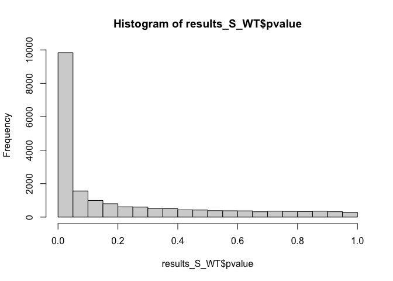

```r
hist(results_S_WT$pvalue)
```

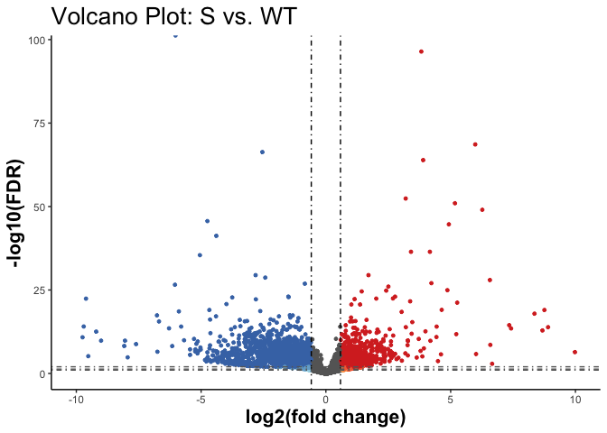

```r
### Volcano plot
generate_volcano(results_S_WT, "S", "WT")
```

## 3.2 M vs WT

```r
results_M_WT = get_dds_res(wald_dds,
                             contrast = c("condition", "CCSER1_M", "WT"),
                             ensembl.genes,
                             shrink = TRUE)
```

```
[1] "condition_CCSER1_M_vs_WT"
```

```
using 'apeglm' for LFC shrinkage. If used in published research, please cite:
    Zhu, A., Ibrahim, J.G., Love, M.I. (2018) Heavy-tailed prior distributions for
    sequence count data: removing the noise and preserving large differences.
    Bioinformatics. https://doi.org/10.1093/bioinformatics/bty895
```

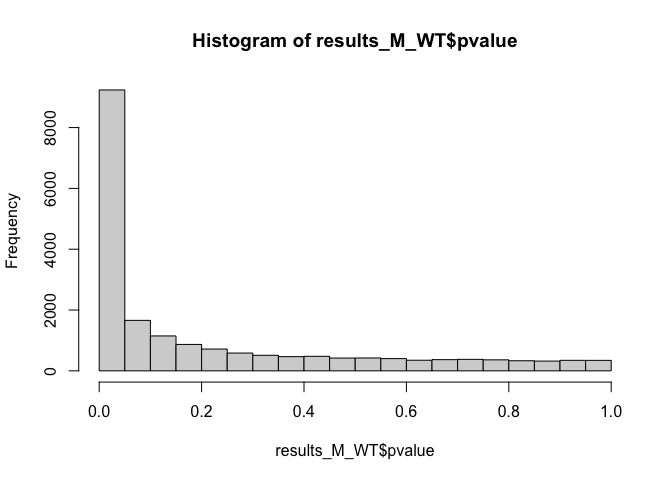

```r
hist(results_M_WT$pvalue)
```

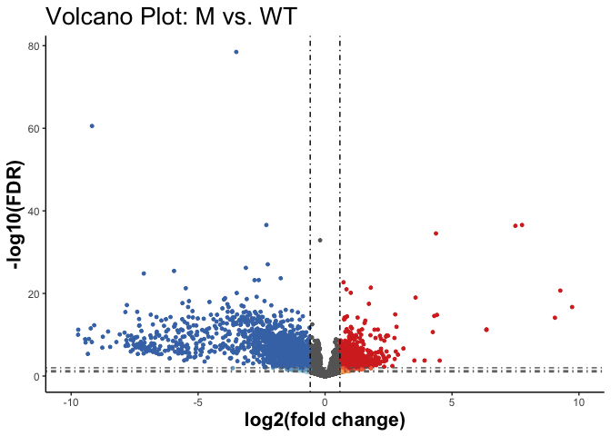

```r
### Volcano plot
generate_volcano(results_M_WT, "M", "WT")
```

## 3.3 Compile and export

```r
## Saving this to compile later

compname <- "M_vs_WT"

M_vs_WT <- results_M_WT[ ,c("baseMean", "log2FoldChange", "padj")]
colnames(M_vs_WT) <- c(paste0(compname, "_baseMean"),
                         paste0(compname, "_log2fc"),
                         paste0(compname, "_padj"))
M_vs_WT$lfcShrink = TRUE


compname <- "S_vs_WT"

S_vs_WT <- results_S_WT[ ,c("baseMean", "log2FoldChange", "padj")]
colnames(S_vs_WT) <- c(paste0(compname, "_baseMean"),
                         paste0(compname, "_log2fc"),
                         paste0(compname, "_padj"))
```

Check that they have same number of rows:

```r
nrow(M_vs_WT) == nrow(S_vs_WT)
```

```
[1] TRUE
```

```r
df_compiled <- cbind(M_vs_WT, S_vs_WT)

head(df_compiled)
```

```
DataFrame with 6 rows and 7 columns
                   M_vs_WT_baseMean M_vs_WT_log2fc M_vs_WT_padj lfcShrink
                          <numeric>      <numeric>    <numeric> <logical>
ENSDARG00000000001          38.0096      0.2185777   0.39652169      TRUE
ENSDARG00000000002         485.4449      0.0691765   0.74457807      TRUE
ENSDARG00000000018         219.3218     -0.4513717   0.00698570      TRUE
ENSDARG00000000019         582.1684      0.1057458   0.37894739      TRUE
ENSDARG00000000068         949.6341     -0.0978355   0.52631514      TRUE
ENSDARG00000000069         506.3664     -0.3698838   0.00437913      TRUE
                   S_vs_WT_baseMean S_vs_WT_log2fc S_vs_WT_padj
                          <numeric>      <numeric>    <numeric>
ENSDARG00000000001          38.0096      0.0326230    0.9081479
ENSDARG00000000002         485.4449     -0.1196931    0.5364547
ENSDARG00000000018         219.3218     -0.4460813    0.0071903
ENSDARG00000000019         582.1684      0.0645156    0.5923788
ENSDARG00000000068         949.6341     -0.1158186    0.4638734
ENSDARG00000000069         506.3664     -0.2301643    0.0783122
```

```r
write.csv(df_compiled, file = paste0(output_dir, "master_de_list.csv"))
```

# 4 Pairwise comparison plots

How similar are M and S? In other words, if a gene goes up in M vs WT, does it also go up in S vs WT?

To answer this question, we use a pairwise crossplot. We plot **log2FoldChange(S vs WT)** on the x-axis, and the **log2FoldChange(M vs WT)** on the y-axis.

We can think of this as a 2D volcano plot, where one volcano plot is on the x axis while the other is on the y-axis.

This divides the plot into 4 quadrants:

- Top right: Up in S, up in M
- Bottom left: Down in S, down in M
- Top left: Down in S, up in M
- Bottom right: Up in S, down in M

which correspond to downregulation and upregulation respectively.

## 4.1 M-S-all

```r
### Note the order of S and WT - S here is the numerator, WT is the denominator
c1_WT = results(wald_dds, contrast = c("condition", "CCSER1_S", "WT"),
                                filter=rowMeans(counts(wald_dds, normalized=TRUE)),
                                test="Wald", alpha=0.1, independentFiltering=TRUE)

c1_WT <- lfcShrink(wald_dds,
                    coef = "condition_CCSER1_S_vs_WT",
                    res = c1_WT,
                    type = "apeglm", parallel = TRUE)
```

```
using 'apeglm' for LFC shrinkage. If used in published research, please cite:
    Zhu, A., Ibrahim, J.G., Love, M.I. (2018) Heavy-tailed prior distributions for
    sequence count data: removing the noise and preserving large differences.
    Bioinformatics. https://doi.org/10.1093/bioinformatics/bty895
```

```r
c2_WT = results(wald_dds, contrast = c("condition", "CCSER1_M", "WT"),
                                filter=rowMeans(counts(wald_dds, normalized=TRUE)),
                                test="Wald", alpha=0.1, independentFiltering=TRUE)

c2_WT <- lfcShrink(wald_dds,
                    coef = "condition_CCSER1_M_vs_WT",
                    res = c2_WT,
                    type = "apeglm", parallel = TRUE)
```

```
using 'apeglm' for LFC shrinkage. If used in published research, please cite:
    Zhu, A., Ibrahim, J.G., Love, M.I. (2018) Heavy-tailed prior distributions for
    sequence count data: removing the noise and preserving large differences.
    Bioinformatics. https://doi.org/10.1093/bioinformatics/bty895
```

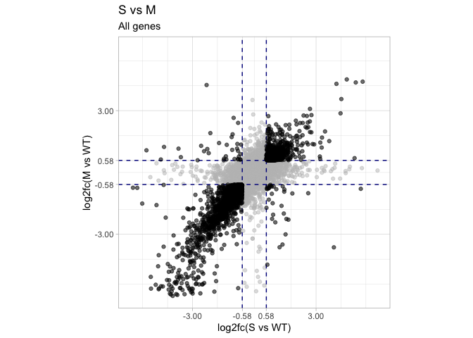

```r
dat <- data.frame(
  gene_id = rownames(c1_WT),
  c1_vs_WT_fc = c1_WT$log2FoldChange,
  c1_vs_WT_padj = c1_WT$padj,
  c2_vs_WT_fc = c2_WT$log2FoldChange,
  c2_vs_WT_padj = c2_WT$padj)

dat$gene_name = ensembl.genes$external_gene_name[match(dat$gene_id, ensembl.genes$gene_id)]

# Plot
ggplot(dat, aes(x = c1_vs_WT_fc, y = c2_vs_WT_fc, label = gene_id)) +
  geom_point(alpha = 0.5) +
  geom_hline(yintercept = lfc.threshold, color = "darkblue", linetype = "dashed") +
  geom_hline(yintercept = -lfc.threshold, color = "darkblue", linetype = "dashed") +
  geom_vline(xintercept = -lfc.threshold, color = "darkblue", linetype = "dashed") +
  geom_vline(xintercept = lfc.threshold, color = "darkblue", linetype = "dashed") +
  labs(title = "S vs M",
       subtitle = "All genes",
       x = "log2fc(S vs WT)",
       y = "log2fc(M vs WT)") +
  scale_x_continuous(limits = c(-6, 6), breaks = c(-20, -3, -0.58,
                                                    0.58, 3, 20)) +
  scale_y_continuous(limits = c(-6, 6), breaks = c(-20, -3, -0.58,
                                                    0.58, 3, 20)) +
  gghighlight::gghighlight(abs(c1_vs_WT_fc) > lfc.threshold & abs(c2_vs_WT_fc) > lfc.threshold,
                           line_label_type = "ggrepel_label") +
  theme_light() +
  coord_fixed()
```

### 4.1.1 Common (top right and bottom left quadrant)

These two quadrants contain genes that are changing **similarly** in M and S. In other words, if this gene is upregulated in M, it is also upregulated in S.

We keep only genes that have an absolute fold change of > 1.5 - in other words, the black dots in the top right and bottom left quadrant of the previous plot. For now, we will not implement any filtering based on `padj`.

**GO enrichments**

**Number of genes (without filtering for padj):**

```r
top_right <- dat[(dat$c1_vs_WT_fc) > lfc.threshold & (dat$c2_vs_WT_fc) > lfc.threshold, ]$gene_id
bottom_left <- dat[(dat$c1_vs_WT_fc) < -lfc.threshold & (dat$c2_vs_WT_fc) < -lfc.threshold, ]$gene_id

signif_genes <- c(top_right, bottom_left)

common_signif <- signif_genes

length(signif_genes)
```

```
[1] 3103
```

**GO enrichment:**

```
Running GO for organism = zebrafish
```

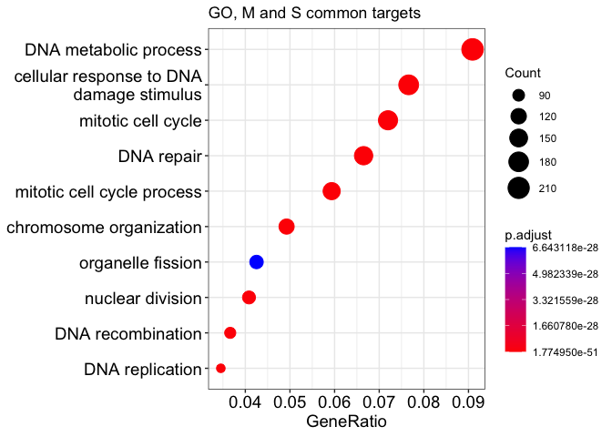

```
[1] "291 enrichments found"
```

```r
ego <- plotEGO_dr(signif_genes, universe = rownames(dds),
               ont = "BP",
               title = "GO, M and S common targets")
```

**KEGG enrichments**

```
Running KEGG for organism = zebrafish
```

```
Reading KEGG annotation online: "https://rest.kegg.jp/link/dre/pathway"...
```

```
Reading KEGG annotation online: "https://rest.kegg.jp/list/pathway/dre"...
```

```
Reading KEGG annotation online: "https://rest.kegg.jp/conv/ncbi-geneid/dre"...
```

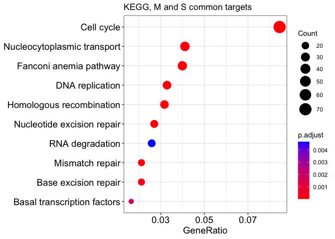

```
[1] "13 enrichments found"
```

```r
# Plot
ekegg <- plotKEGG_dr(get_entrez(ensembl_ids = signif_genes,
                                ensembl_genes = ensembl.genes),
                     title = "KEGG, M and S common targets")
```

```r
# Table
ekegg[ ,colnames(ekegg) %in% c("Description", "GeneRatio", "p.adjust", "geneID")]
```

|  | Description | GeneRatio | p.adjust | geneID |
| --- | --- | --- | --- | --- |
| dre04110 | Cell cycle | 72/852 | 0.0000000 | mad2l1/skp2/smad2/rb1/ccnh/anapc5/orc3/cdc6/cdc25b/ddx11/ccn…… |
| dre03460 | Fanconi anemia pathway | 34/852 | 0.0000000 | rpa3/rpa1/fancl/ercc4/fancf/fancg/fanci/poli/ercc1/rpa2/wdr48b/rad51/top3a/fancd2/fancc/usp1/slx4/fan1/atrip/ube2t/fance/rad51c/mus81/polh/cenps/brip1/pms2/palb2/eme1/blm/brca2/faap100/atr/cenpx |
| dre03030 | DNA replication | 28/852 | 0.0000000 | rpa3/rpa1/rnaseh2b/fen1/rfc2/pola2/mcm5/pold1/mcm6l/rpa2/mcm3l/mcm4/prim1/rfc4/rnaseh1/pola1/prim2/pcna/rfc1/rfc3/pole/lig1/pold3/dna2/pold2/pole2/mcm7/mcm2 |
| dre03440 | Homologous recombination | 27/852 | 0.0000000 | rpa3/rpa1/rad52/xrcc3/rad54l/rad51d/pold1/rad51b/rpa2/nbn/rad51/abraxas1/rbbp8/top3a/topbp1/rad51c/mus81/brip1/pold3/palb2/bard1/eme1/blm/brca2/rad54b/pold2/mre11a |
| dre03430 | Mismatch repair | 18/852 | 0.0000000 | rpa3/rpa1/rfc2/msh2/pold1/rpa2/rfc4/pcna/rfc1/rfc3/mlh3/exo1/lig1/msh3/pms2/pold3/pold2/msh6 |
| dre03013 | Nucleocytoplasmic transport | 35/852 | 0.0000004 | nup155/ddx19b/cse1l/snupn/nup35/ncbp2/thoc7/tprb/nup62l/ndc1…… |
| dre03420 | Nucleotide excision repair | 23/852 | 0.0000017 | mnat1/rpa3/rpa1/ccnh/ercc4/rfc2/ercc2/gtf2h1/pold1/ercc1/rpa2/polr2i/rfc4/cdk7/pcna/rfc1/rfc3/pole/lig1/polr2m/pold3/pold2/pole2 |
| dre03410 | Base excision repair | 18/852 | 0.0001452 | polb/xrcc1/fen1/rfc2/neil3/aptx/pold1/rfc4/unga/pcna/rfc1/rfc3/pole/lig1/pold3/pold2/pole2/pnkp |
| dre03022 | Basal transcription factors | 14/852 | 0.0018906 | mnat1/gtf2f2b/ccnh/gtf2a1/tbp/taf5/ercc2/taf5l/gtf2h1/cdk7/gtf2a2/gtf2a1l/taf4b/tbpl2 |
| dre03018 | RNA degradation | 22/852 | 0.0046598 | exosc9/wdr61/cnot6a/mtrex/patl1/zgc:103759/c1d/exosc2/cnot7/lsm1/cnot10/ddx6/tent4a/skiv2l/exosc8/btg3/lsm5/lsm3/exosc7/xrn2/parn/exosc4 |
| dre04914 | Progesterone-mediated oocyte maturation | 26/852 | 0.0066218 | mad2l1/cpeb1b/anapc5/hsp90aa1.1/cdc25b/ccna2/aurka/cdk2/mad1l1/ccnb2/mad2l2/ccna1/cdc23/cpeb1a/ccnb1/cpeb2/cdc16/cdc27/plk1/spdya/mos/anapc1/bub1/cdk1/anapc10/kif22 |
| dre04114 | Oocyte meiosis | 32/852 | 0.0081490 | mad2l1/cpeb1b/anapc5/aurka/smc1b/fbxw11b/ppp3cb/cdk2/mad1l1/ccnb2/fbxo5/mad2l2/cdc23/cpeb1a/ccnb1/cpeb2/cdc16/cdc27/plk1/spdya/mos/espl1/pttg1/anapc1/bub1/cdk1/anapc10/ccne1/cdc20/sgo1/fbxo43/fbxw11a |
| dre03450 | Non-homologous end-joining | 6/852 | 0.0404522 | xrcc4/fen1/lig4/xrcc5/polm/mre11a |

## 4.2 M-S-filt

Filter and plot:

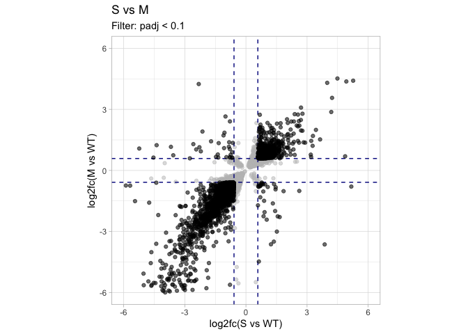

```r
# Keep only genes with padj < 0.1 in at least 1 comparison
dat_filt <- na.omit(dat[dat$c1_vs_WT_padj < 0.1 & dat$c2_vs_WT_padj < 0.1, ])

# Plot
ggplot(dat_filt, aes(x = c1_vs_WT_fc, y = c2_vs_WT_fc, label = gene_id)) +
  geom_point(alpha = 0.5) +
  geom_hline(yintercept = lfc.threshold, color = "darkblue", linetype = "dashed") +
  geom_hline(yintercept = -lfc.threshold, color = "darkblue", linetype = "dashed") +
  geom_vline(xintercept = -lfc.threshold, color = "darkblue", linetype = "dashed") +
  geom_vline(xintercept = lfc.threshold, color = "darkblue", linetype = "dashed") +
  labs(title = "S vs M",
       subtitle = "Filter: padj < 0.1",
       x = "log2fc(S vs WT)",
       y = "log2fc(M vs WT)") +
  scale_x_continuous(limits = c(-6, 6)) +
  scale_y_continuous(limits = c(-6, 6)) +
  gghighlight::gghighlight(abs(c1_vs_WT_fc) > lfc.threshold & abs(c2_vs_WT_fc) > lfc.threshold,
                           line_label_type = "ggrepel_label") +
  theme_light() +
  coord_fixed()
```

# 5 Venn diagram

Wald test - M vs WT. How many genes are significant (padj < 0.1 & abs(foldChange) > 1.5)?

```r
### Note the order of M and WT - M here is the numerator, WT is the denominator
res = results(wald_dds, contrast = c("condition", "CCSER1_M", "WT"),
                                filter=rowMeans(counts(wald_dds, normalized=TRUE)),
                                test="Wald", alpha=0.1, independentFiltering=TRUE)

res = lfcShrink(wald_dds,
                coef = "condition_CCSER1_M_vs_WT",
                res = res,
                type = "apeglm", parallel = TRUE)
```

```
using 'apeglm' for LFC shrinkage. If used in published research, please cite:
    Zhu, A., Ibrahim, J.G., Love, M.I. (2018) Heavy-tailed prior distributions for
    sequence count data: removing the noise and preserving large differences.
    Bioinformatics. https://doi.org/10.1093/bioinformatics/bty895
```

```r
res$gene_biotype= ensembl.genes$gene_biotype[match(row.names(res), ensembl.genes$gene_id)]
res$external_gene_name= ensembl.genes$external_gene_name[match(row.names(res), ensembl.genes$gene_id)]

M_signif <- res[na.omit(res$padj < 0.1 & abs(res$log2FoldChange) > lfc.threshold), ]

dim(M_signif)
```

```
[1] 4438    6
```

Wald test - S vs WT. How many genes are significant (padj < 0.1 & abs(foldChange) > 1.5)?

```r
### Note the order of S and WT - S here is the numerator, WT is the denominator
res = results(wald_dds, contrast = c("condition", "CCSER1_S", "WT"),
                                filter=rowMeans(counts(wald_dds, normalized=TRUE)),
                                test="Wald", alpha=0.1, independentFiltering=TRUE)
res = lfcShrink(wald_dds,
                coef = "condition_CCSER1_S_vs_WT",
                res = res,
                type = "apeglm", parallel = TRUE)
```

```
using 'apeglm' for LFC shrinkage. If used in published research, please cite:
    Zhu, A., Ibrahim, J.G., Love, M.I. (2018) Heavy-tailed prior distributions for
    sequence count data: removing the noise and preserving large differences.
    Bioinformatics. https://doi.org/10.1093/bioinformatics/bty895
```

```r
res$gene_biotype= ensembl.genes$gene_biotype[match(row.names(res), ensembl.genes$gene_id)]
res$external_gene_name= ensembl.genes$external_gene_name[match(row.names(res), ensembl.genes$gene_id)]

S_signif <- res[na.omit(res$padj < 0.1 & abs(res$log2FoldChange) > lfc.threshold), ]

dim(S_signif)
```

```
[1] 5222    6
```

Venn diagram:

```r
genelist <- list("M" = rownames(M_signif),
                 "S" = rownames(S_signif))
```

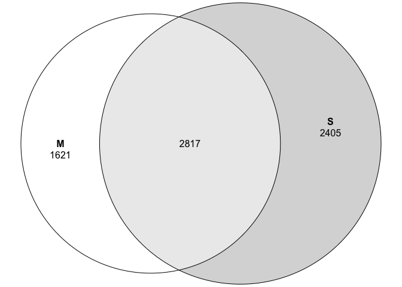

```r
# An area-proportional plot
plot(euler(genelist), quantities = TRUE)
```

Splitting this into up and down:

```r
genelist_updown <- list("M_up" = rownames(M_signif[M_signif$log2FoldChange > lfc.threshold, ]),
                 "M_down" = rownames(M_signif[M_signif$log2FoldChange < -lfc.threshold, ]),
                 "S_up" = rownames(S_signif[S_signif$log2FoldChange > lfc.threshold, ]),
                 "S_down" = rownames(S_signif[S_signif$log2FoldChange < -lfc.threshold, ]))
```

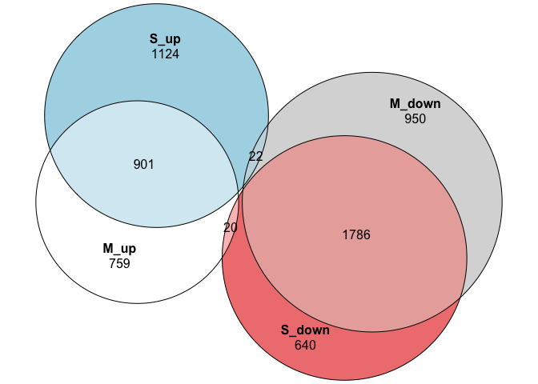

```r
# An area-proportional plot
plot(euler(genelist_updown), quantities = TRUE)
```

Export